# Data Udacity

Christoph Knoop

2 April 2018

# Quality of Red Wine by Christoph Knoop

# Abstract

What makes a good wine? Centuries of tradition, solid craftsmanship? I’m sure it is. But the quality of a wine also has something to do with what it contains chemically.The Question: Can we derive its quality from the chemical composition of a wine?

# Source of Dataset

P. Cortez, A. Cerdeira, F. Almeida, T. Matos and J. Reis. Modeling wine preferences by data mining from physicochemical properties. In Decision Support Systems, Elsevier, 47(4):547-553. ISSN: 0167-9236.

Available at: [@Elsevier] http://dx.doi.org/10.1016/j.dss.2009.05.016 [Pre-press (pdf)] http://www3.dsi.uminho.pt/pcortez/winequality09.pdf [bib] http://www3.dsi.uminho.pt/pcortez/dss09.bib

# Analysis

**A first look at the dataset**

```
## [1] 1599   13
```

```
##        X          fixed.acidity   volatile.acidity  citric.acid
##  Min.   :   1.0   Min.   : 4.60   Min.   :0.1200   Min.   :0.000
##  1st Qu.: 400.5   1st Qu.: 7.10   1st Qu.:0.3900   1st Qu.:0.090
##  Median : 800.0   Median : 7.90   Median :0.5200   Median :0.260
##  Mean   : 800.0   Mean   : 8.32   Mean   :0.5278   Mean   :0.271
##  3rd Qu.:1199.5   3rd Qu.: 9.20   3rd Qu.:0.6400   3rd Qu.:0.420
##  Max.   :1599.0   Max.   :15.90   Max.   :1.5800   Max.   :1.000
##  residual.sugar     chlorides       free.sulfur.dioxide
##  Min.   : 0.900   Min.   :0.01200   Min.   : 1.00
##  1st Qu.: 1.900   1st Qu.:0.07000   1st Qu.: 7.00
##  Median : 2.200   Median :0.07900   Median :14.00
##  Mean   : 2.539   Mean   :0.08747   Mean   :15.87
##  3rd Qu.: 2.600   3rd Qu.:0.09000   3rd Qu.:21.00
##  Max.   :15.500   Max.   :0.61100   Max.   :72.00
##  total.sulfur.dioxide    density             pH          sulphates
##  Min.   :  6.00       Min.   :0.9901   Min.   :2.740   Min.   :0.3300
##  1st Qu.: 22.00       1st Qu.:0.9956   1st Qu.:3.210   1st Qu.:0.5500
##  Median : 38.00       Median :0.9968   Median :3.310   Median :0.6200
##  Mean   : 46.47       Mean   :0.9967   Mean   :3.311   Mean   :0.6581
##  3rd Qu.: 62.00       3rd Qu.:0.9978   3rd Qu.:3.400   3rd Qu.:0.7300
##  Max.   :289.00       Max.   :1.0037   Max.   :4.010   Max.   :2.0000
##     alcohol         quality
##  Min.   : 8.40   Min.   :3.000
##  1st Qu.: 9.50   1st Qu.:5.000
##  Median :10.20   Median :6.000
##  Mean   :10.42   Mean   :5.636
##  3rd Qu.:11.10   3rd Qu.:6.000
##  Max.   :14.90   Max.   :8.000
```

```
## 'data.frame':    1599 obs. of  13 variables:
##  $ X                   : int  1 2 3 4 5 6 7 8 9 10 ...
##  $ fixed.acidity       : num  7.4 7.8 7.8 11.2 7.4 7.4 7.9 7.3 7.8 7.5 ...
##  $ volatile.acidity    : num  0.7 0.88 0.76 0.28 0.7 0.66 0.6 0.65 0.58 0.5 ...
##  $ citric.acid         : num  0 0 0.04 0.56 0 0 0.06 0 0.02 0.36 ...
##  $ residual.sugar      : num  1.9 2.6 2.3 1.9 1.9 1.8 1.6 1.2 2 6.1 ...
##  $ chlorides           : num  0.076 0.098 0.092 0.075 0.076 0.075 0.069 0.065 0.073 0.071 ...
##  $ free.sulfur.dioxide : num  11 25 15 17 11 13 15 15 9 17 ...
##  $ total.sulfur.dioxide: num  34 67 54 60 34 40 59 21 18 102 ...
##  $ density             : num  0.998 0.997 0.997 0.998 0.998 ...
##  $ pH                  : num  3.51 3.2 3.26 3.16 3.51 3.51 3.3 3.39 3.36 3.35 ...
##  $ sulphates           : num  0.56 0.68 0.65 0.58 0.56 0.56 0.46 0.47 0.57 0.8 ...
##  $ alcohol             : num  9.4 9.8 9.8 9.8 9.4 9.4 9.4 10 9.5 10.5 ...
##  $ quality             : int  5 5 5 6 5 5 5 7 7 5 ...
```

# Explanation of the attributes

This explanation is part of the original dataset: **1 - fixed acidity:** most acids involved with wine or fixed or nonvolatile (do not evaporate readily)

**2 - volatile acidity:** the amount of acetic acid in wine, which at too high of levels can lead to an unpleasant, vinegar taste

**3 - citric acid:** found in small quantities, citric acid can add ‘freshness’ and flavor to wines

**4 - residual sugar:** the amount of sugar remaining after fermentation stops, it’s rare to find wines with less than 1 gram/liter and wines with greater than 45 grams/liter are considered sweet

**5 - chlorides:** the amount of salt in the wine

**6 - free sulfur dioxide:** the free form of SO2 exists in equilibrium between molecular SO2 (as a dissolved gas) and bisulfite ion; it prevents microbial growth and the oxidation of wine

**7 - total sulfur dioxide:** amount of free and bound forms of S02; in low concentrations, SO2 is mostly undetectable in wine, but at free SO2 concentrations over 50 ppm, SO2 becomes evident in the nose and taste of wine

**8 - density:** the density of water is close to that of water depending on the percent alcohol and sugar content

**9 - pH:** describes how acidic or basic a wine is on a scale from 0 (very acidic) to 14 (very basic); most wines are between 3-4 on the pH scale

**10 - sulphates:** a wine additive which can contribute to sulfur dioxide gas (S02) levels, wich acts as an antimicrobial and antioxidant

**11 - alcohol:** the percent alcohol content of the wine

Output variable (based on sensory data): **12 - quality** (score between 0 and 10)

# Univariate Plots Section

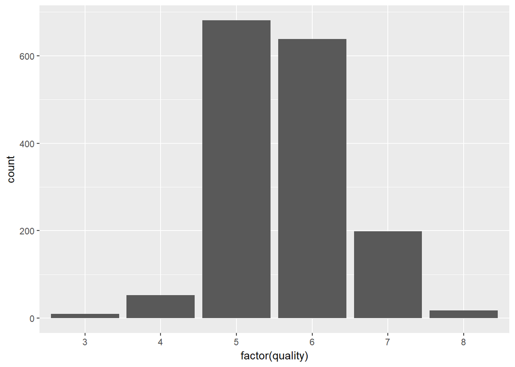

```
##   3   4   5   6   7   8
##  10  53 681 638 199  18
```

As we can see, most of the wines examined are of average **quality**. On a scale of 1 to 10, the wines of quality level 5 make up the largest sample with 681, followed by wines of level 6. 82.49 percent of the wines come from the two middle quality levels 5 and 6. The best categories 9 and 10 are not represented at all in the data set, this also applies to the lowest levels 0 to 2. I introduced a variable with quality.factor. Here the quality assessments are arranged as factor variables.

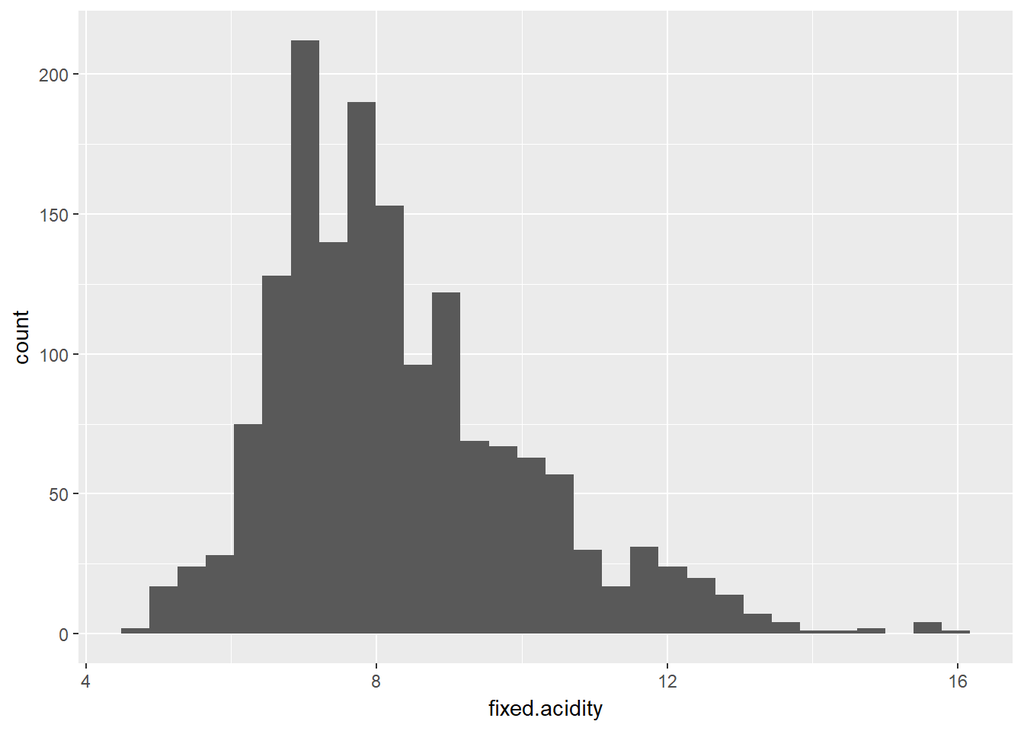

```
##    Min. 1st Qu.  Median    Mean 3rd Qu.    Max.
##    4.60    7.10    7.90    8.32    9.20   15.90
```

The lowest degree of **fixed acidity** is 4.6, the highest is 15.90. Especially in the upper values there are a few prominent outliers (14 and higher). The main part of the wines has an acidity of 7.1 (1st quartile) and 9.20 (3rd quartile). The average is 8.32, the median 7.9.

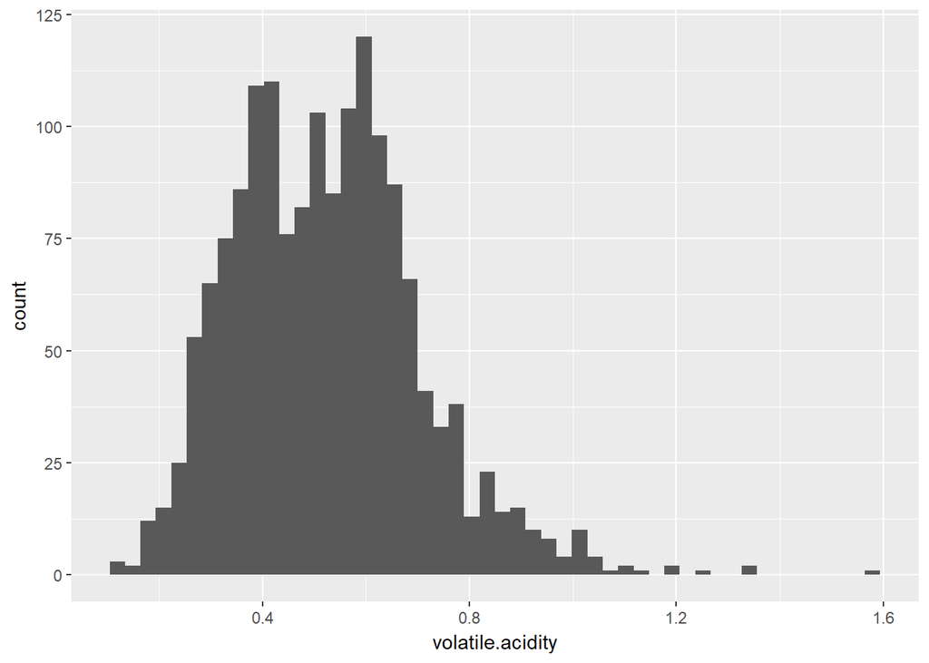

```
##    Min. 1st Qu.  Median    Mean 3rd Qu.    Max.
##  0.1200  0.3900  0.5200  0.5278  0.6400  1.5800
```

The **volatile acidity** is of particular interest, as a high proportion can trigger a vinegar taste of the wine. The lowest acidity in the wines tested is 0.12, the highest is 1.58. Most of the values are between 0.39(1st quartile) and 0.64 (3rd quartile). The average amounts to 0.5278, the median is 0.52. The higher values show some high outliers (more than 1.2). Since a high acid value can lead to a bad taste, the question is interesting whether the high values are reflected in a loss of quality.

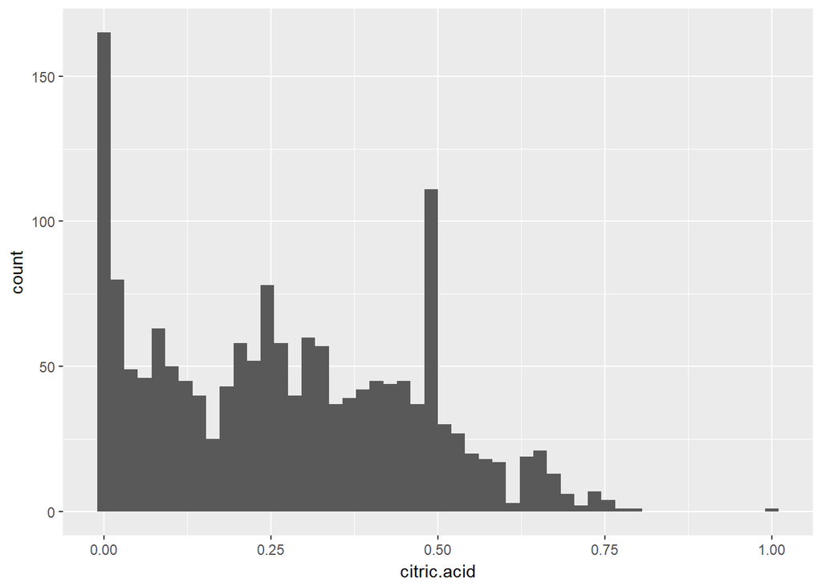

```
##    Min. 1st Qu.  Median    Mean 3rd Qu.    Max.
##   0.000   0.090   0.260   0.271   0.420   1.000
```

**Citric acid** also has a strong influence on the taste. The higher their proportion, the fresher the wine can taste. The question for later analysis: Does a taste altered by citric acid also ensure a higher quality? A look at the histogram shows that many wines do not contain any citric acid at all, the histogram also shows two peaks at an acid content of 0.25 and 0.5. The highest value is a violent outlier and is at 1.

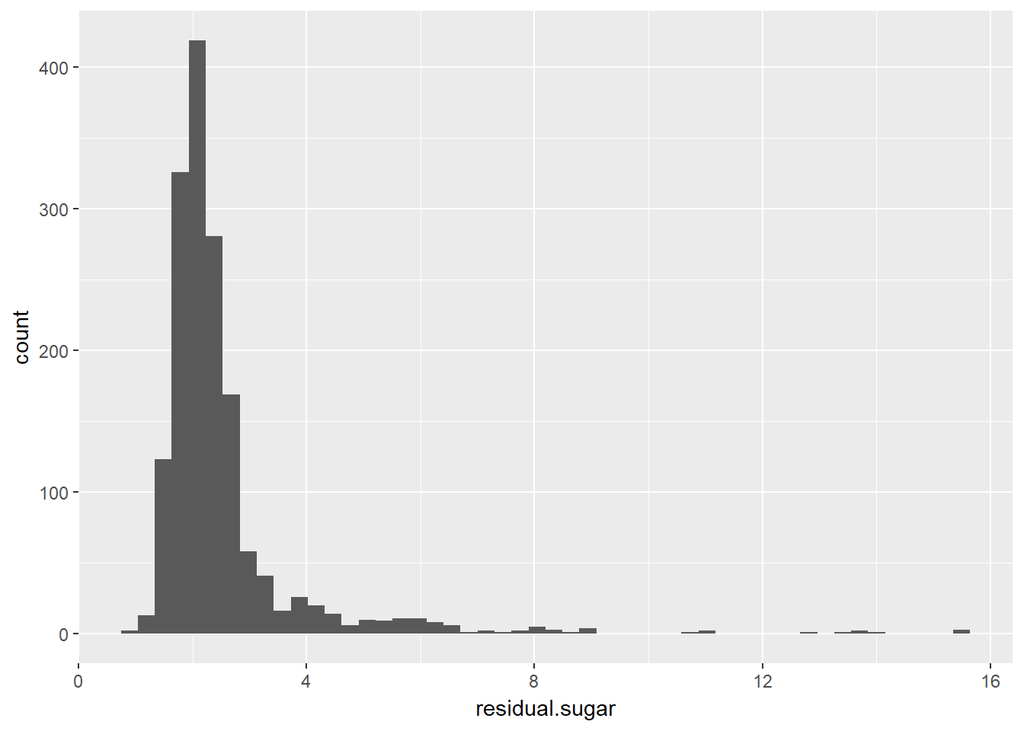

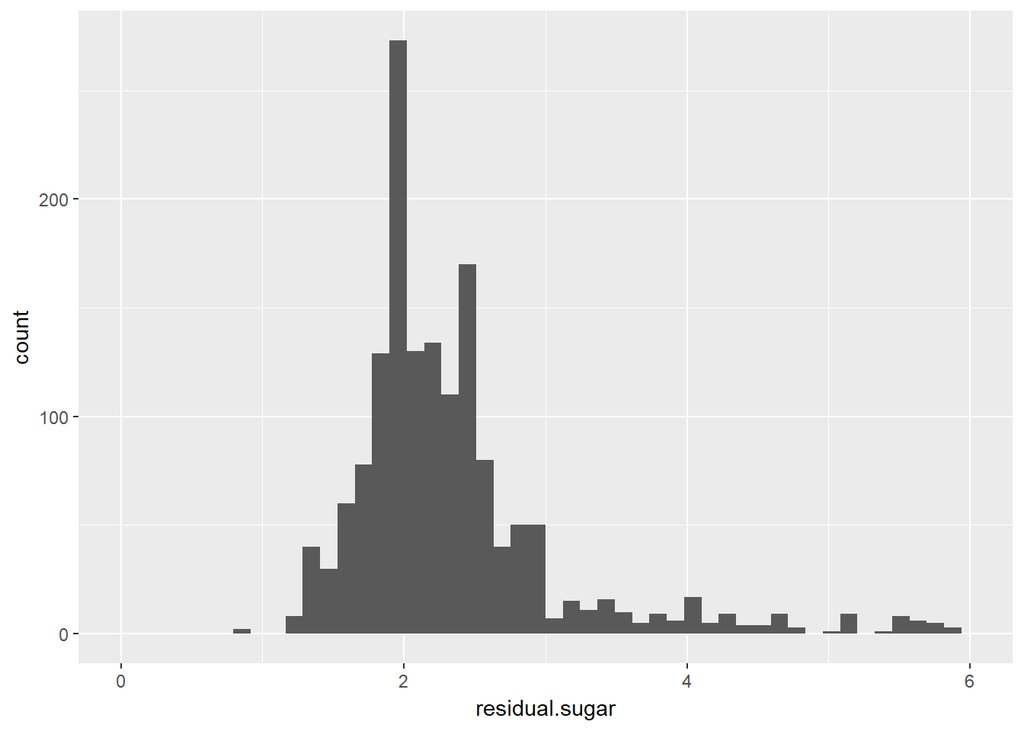

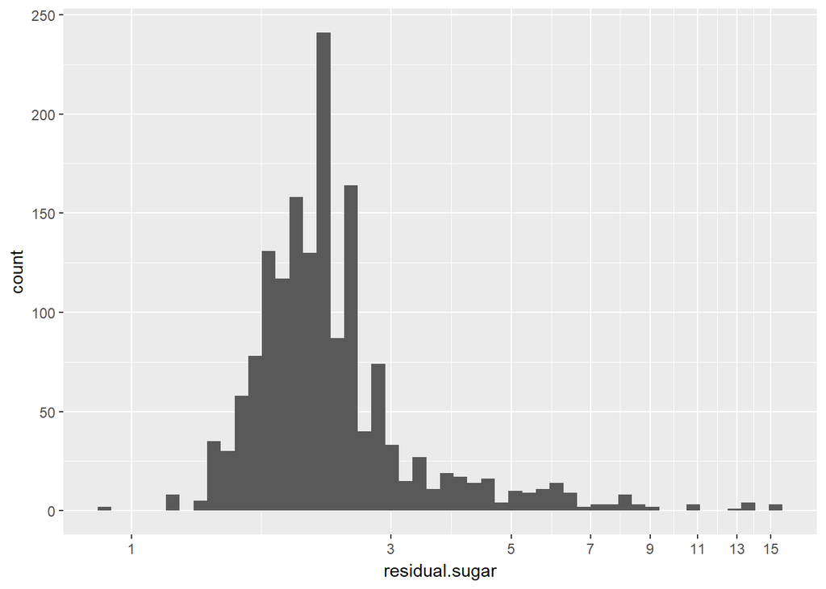

```
##    Min. 1st Qu.  Median    Mean 3rd Qu.    Max.
##   0.900   1.900   2.200   2.539   2.600  15.500
```

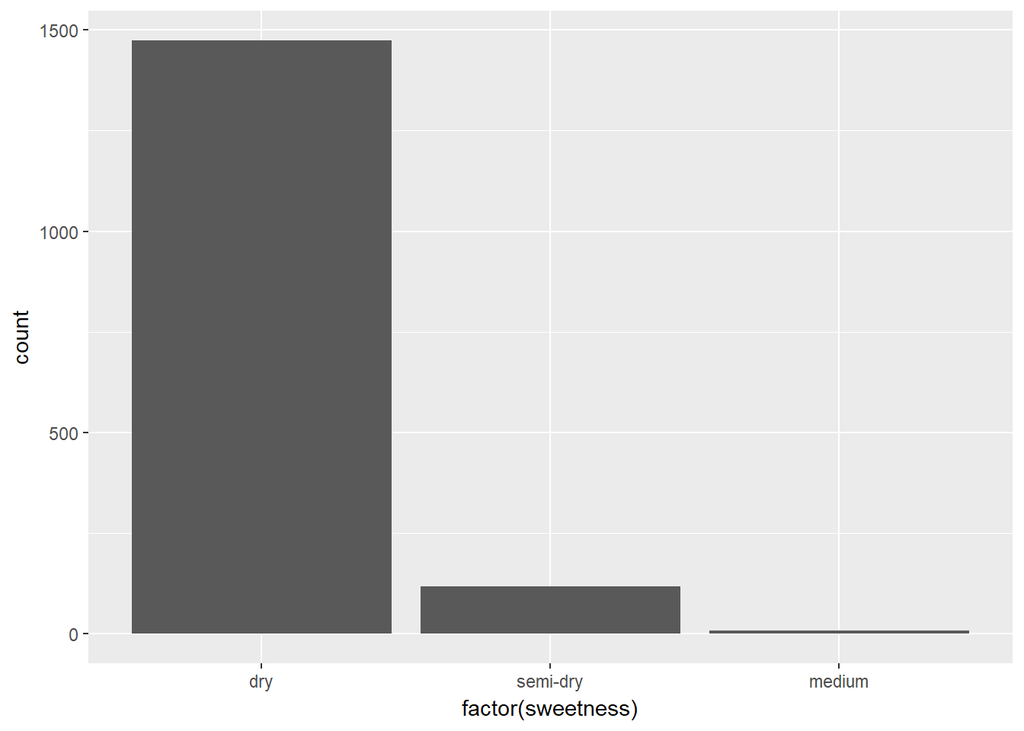

The degree of sweetness of the wine depends on the **residual sugar**. Here it makes sense to create a new variable that divides the wines into four categories. These categories are derived from European Union regulation. According to this, a wine with up to 4 mg sugar per litre is considered dry, between 5 and 12 mg per litre as semi-dry, between 13 and 45 grams per litre as medium and with a sugar value of more than 45 grams per litre as sweet.We call that new variable “sweetness”.

Here is the source: *https://en.wikipedia.org/wiki/Sweetness_of_wine*

In order to increase the significance of our sugar histograms, the second plot is a zoom into the range up to a sugar content of 6 grams per litre. In the third diagram I scaled the X-axis with Log10() to show the distribution even more clearly.

The plots show Most of the wines can be classified in the dry category, between 1.9 (1st quartile) and 2.6 (3rd quartile). However, we have an outlier with a significantly higher sugar content of up to 15.5.

Our variable “sweetness” shows that the majority of the wines examined have the attribute “dry” according to the EU classification.

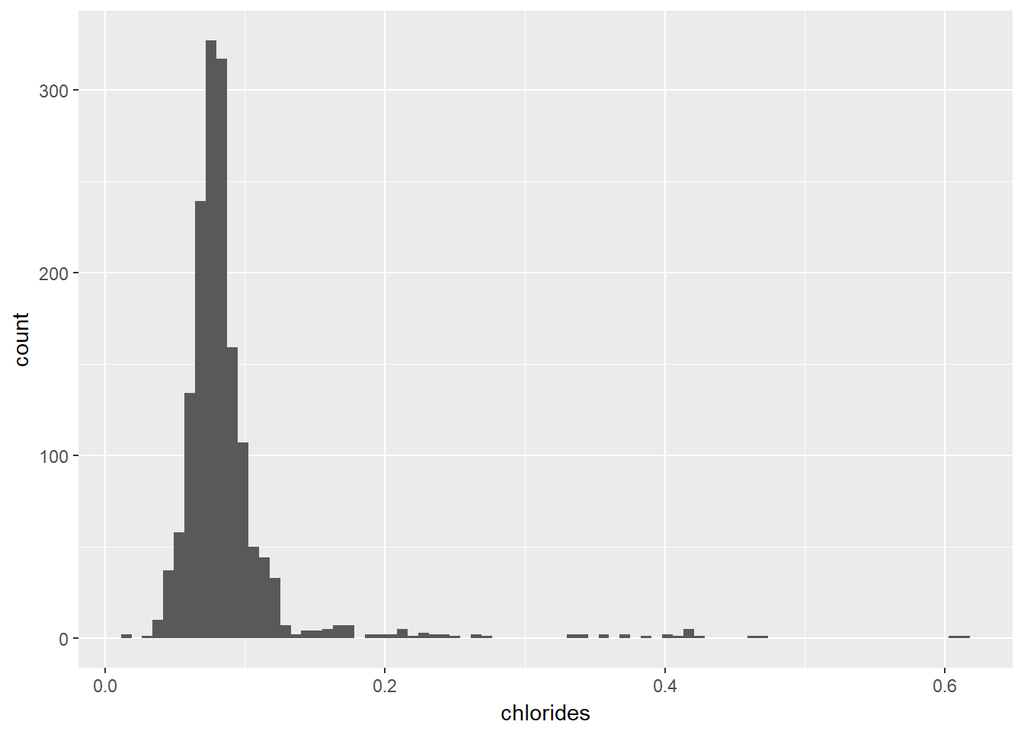

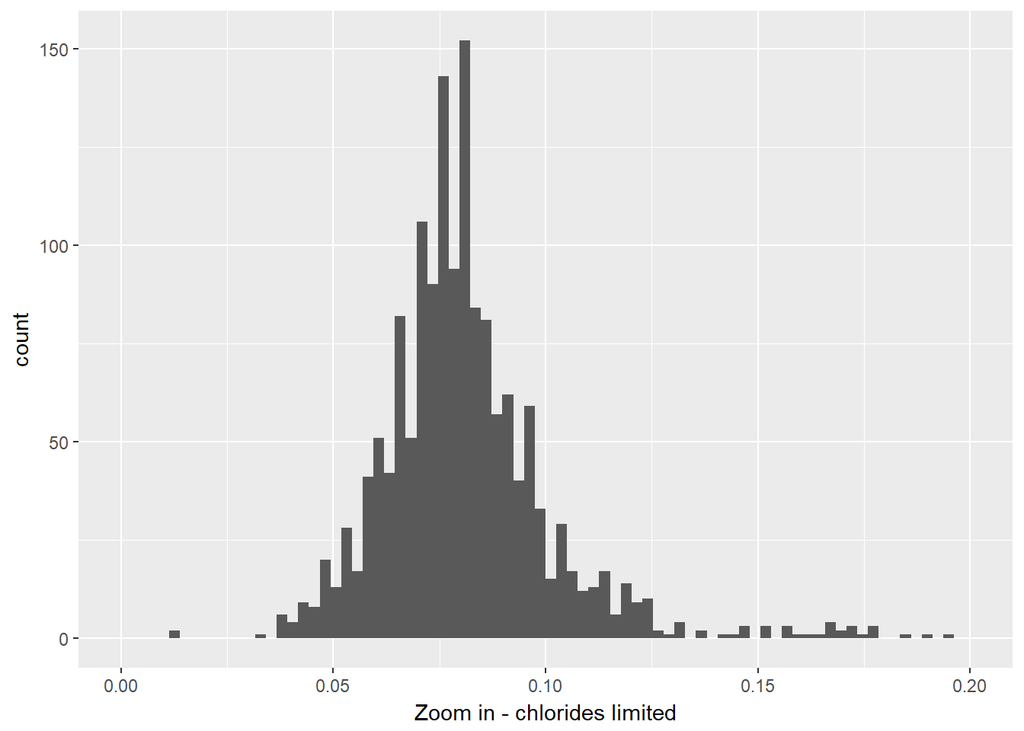

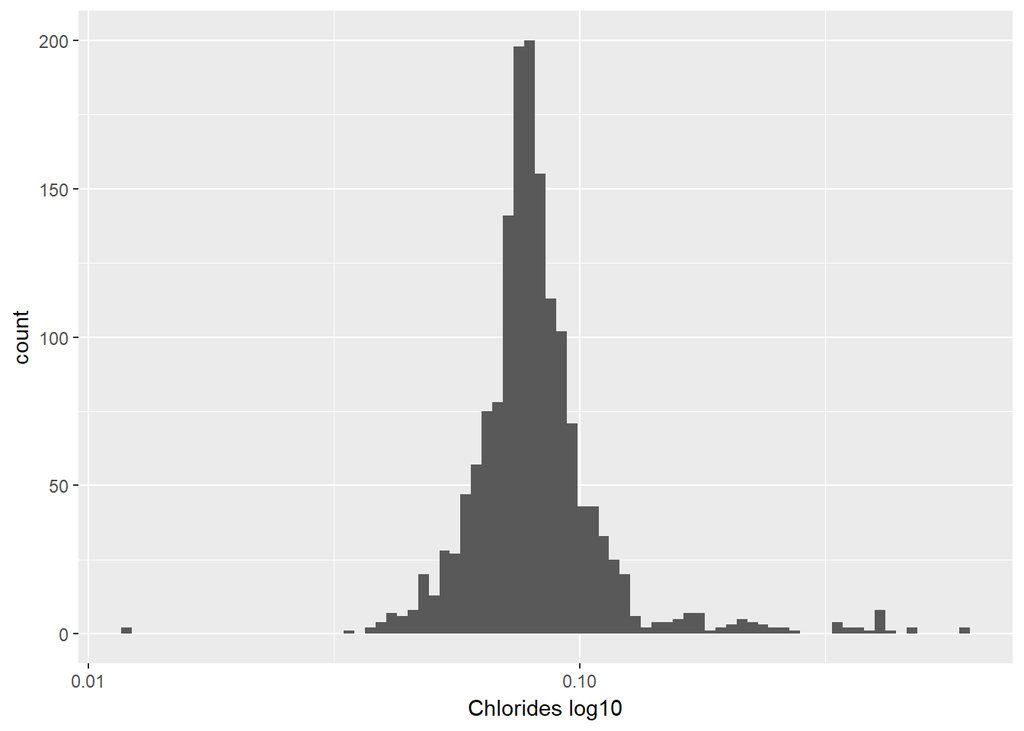

```
##    Min. 1st Qu.  Median    Mean 3rd Qu.    Max.
## 0.01200 0.07000 0.07900 0.08747 0.09000 0.61100
```

Most of the wines have a **sodium chloride** content between 0.07 grams per liter (1st quartile) and 0.09 grams per liter (3rd quartile). The median is 0.079 grams per liter, the average is 0.08747 grams per liter. Occasionally we find outliers of up to 0.611 grams per litre in the wines.

The salt content is responsible for the occurrence of tartar. Whether this has an effect on the evaluation of wine testers will be analysed at a later date.

```
##    Min. 1st Qu.  Median    Mean 3rd Qu.    Max.
##    1.00    7.00   14.00   15.87   21.00   72.00
```

```
##    Min. 1st Qu.  Median    Mean 3rd Qu.    Max.
##    6.00   22.00   38.00   46.47   62.00  289.00
```

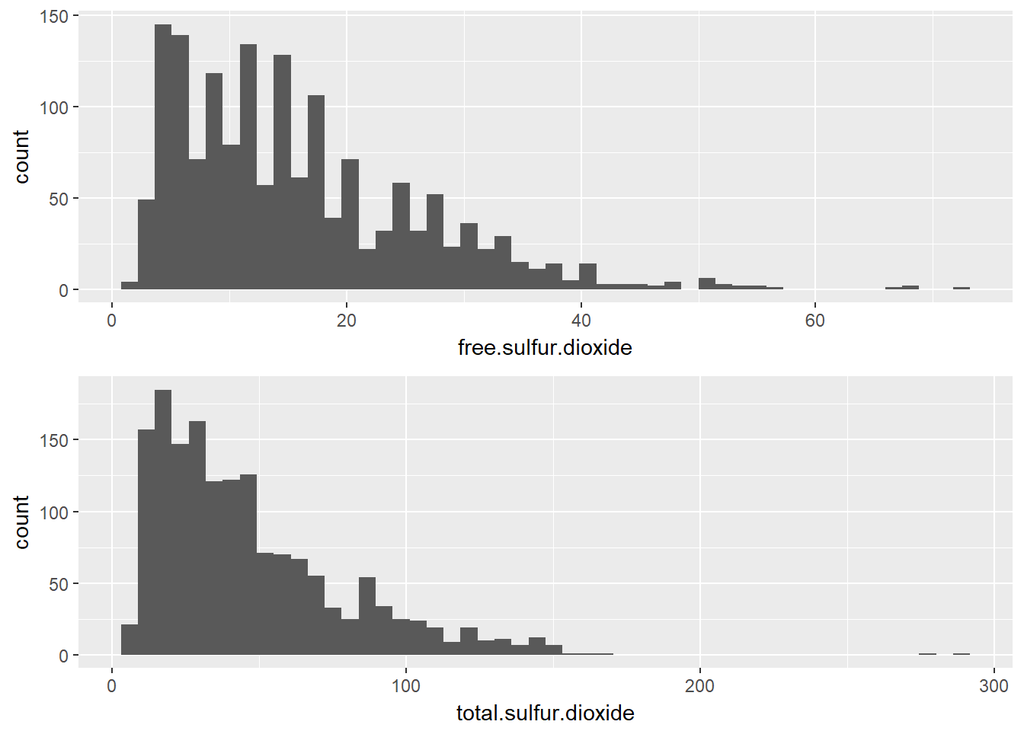

Sulphur is important for the preservation of a wine, otherwise the liquids can oxidize very quickly. Moreover, sulphur enhances the taste, without sulphur a wine would taste more like a path. Above all sweet wines have to be sulphured. There are discussions whether sulphurization has a negative effect on the quality of the wine. We can investigate this later. therefore the question: Does low sulphur ensure more quality?

This free sulphur is what can possibly smell and cause health problems if the wine has been over-sulphured. For the health evaluation it depends therefore on the content of free sulphurous acid. Free sulphur above 50 mg/litre is clearly noticeable.

In our data set, the low value for free sulfur is 1.0, the highest value is 72 (median 14, average 15.87).

The lowest value for total sulphur is 6, the highest is 289, the median is 38, the average is 46.47.

For both values we see a large gap between the 3rd quartile and the highest value. So we are dealing here with extreme outliers.

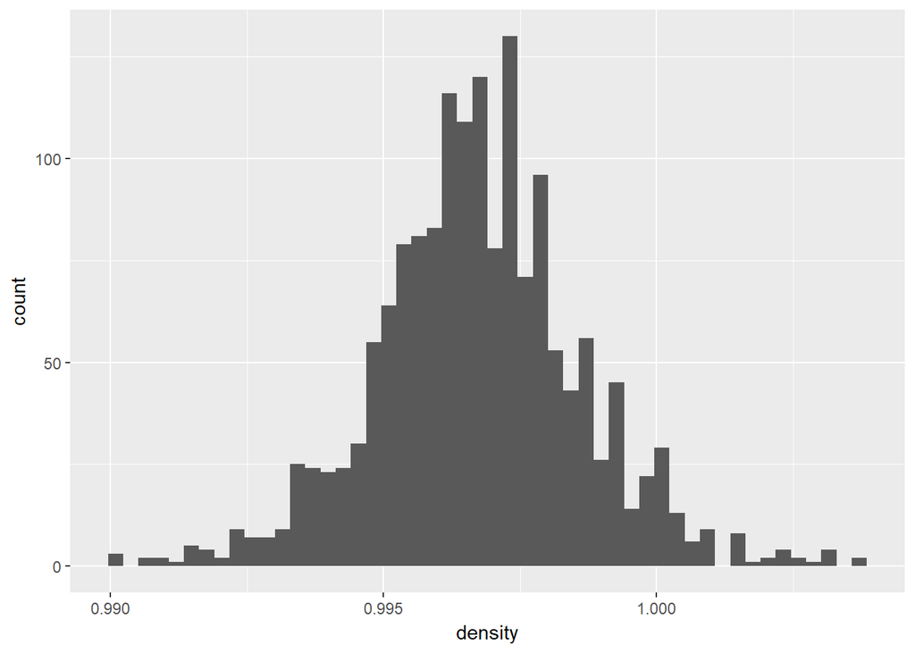

```
##    Min. 1st Qu.  Median    Mean 3rd Qu.    Max.
##  0.9901  0.9956  0.9968  0.9967  0.9978  1.0037
```

The **density of the wine** indicates something for the proportion of must in the liquid. The higher, the heavier the must, for example late ripened grapes with a high sugar content. However, the sugar content of the must is only part of the taste of a wine.

As a rule of thumb, the sweeter a wine, the higher its density.